# Data (Simulation and) Analysis for Speed Listening Experiment

Amy Zhang

## Install and Load Packages

```r
install.packages(c("tidyverse", "afex", "emmeans", "ggpubr","PMCMRplus","ggsignif"))
```

[output not shown]

```r
library(ggplot2)
library(tidyverse)
library(tidyr)
library(afex)
library(emmeans)
library(ggpubr)
library(ggsignif)
library(car)
library(PMCMRplus)
library(effectsize)
library(hrbrthemes)
```

# Data Simulation

### Experiment parameters and responses

Setting experimental parameters for the dataframe, with 4 experimental conditions, 6 trials, and 92 participants.

Response are participants’ performance on each of the 6 trials, with “correct response” represented by “1” and “incorrect response” represented by “0”. Accuracy is calculated based on each participant’s responses across 6 trials.

```r
set.seed(123)  # For reproducibility

nSample <- 92  #total number of participants
nCond <- 4
cond_names <- c("1.0x", "1.5x", "1.7x", "2.0x")
nTrials <- 6
accuracyRate <- 0.85  # Target overall accuracy, should be high since questions were simple

# Generate balanced condition assignments
balanced_conditions <- sample(rep(cond_names, each = nSample / nCond))

# Generate random responses with ~85% accuracy
responses <- matrix(rbinom(nSample * nTrials, size = 1, prob = accuracyRate),
                    nrow = nSample, ncol = nTrials)

# Calculate individual accuracy
individual_accuracy <- rowMeans(responses)
```

### Generate reaction time data

Results are expected to be significant for main effect of conditions and trials.

```r
# Define reaction time distributions for each condition & trial
generate_rt <- function(condition, trial) {
  if (condition == "1.0x") {
    return(rnorm(1, mean = 4500 + (trial * 15), sd = 1000))
  } else if (condition == "1.5x") {
    return(rnorm(1, mean = 5000 + (trial * 20), sd = 1000))
  } else if (condition == "1.7x") {
    return(rnorm(1, mean = 5700 + (trial * 25), sd = 1000))
  } else if (condition == "2.0x") {
    return(rnorm(1, mean = 6000 + (trial * 145), sd = 1000))
  }
}   #rt increases as speed levels increase, and as trial numbers increase.
    #the increase should be more obvious in higher speed conditions


# Generate reaction time data
reaction_times <- matrix(nrow = nSample, ncol = nTrials)
for (i in 1:nSample) {
  for (j in 1:nTrials) {
    reaction_times[i, j] <- generate_rt(balanced_conditions[i], j)
  }
}
```

### Generate Likert scale response

Likert responses for survey questions at the end of experiment. All questions are designed to be positively coded so that higher rating represents higher level of the construct measured in each question (on the scale of 1-6, 1 being “strongly disagree”, 6 being “strongly agree).

```r
# Define custom probability distributions for each Likert question
generate_likert <- function(condition, question) {
  if (question == "knowledge") {
    probs <- rep(1/6, 6)  # Uniform distribution for all conditions
  } else if (question == "interest") {
    probs <- switch(condition,
                    "1.0x" = rep(1/6, 6),
                    "1.5x" = rep(1/6, 6),
                    "1.7x" = c(0.1, 0.12, 0.18, 0.2, 0.2, 0.2),
                    "2.0x" = c(0.12, 0.15, 0.18, 0.2, 0.2, 0.15)
    )
  } else if (question == "attention") {
    probs <- switch(condition,
                    "1.0x" = c(0.1, 0.25, 0.3, 0.2, 0.1, 0.05),
                    "1.5x" = c(0.12, 0.18, 0.25, 0.2, 0.15, 0.1),
                    "1.7x" = c(0.1, 0.1, 0.25, 0.3, 0.15, 0.1),
                    "2.0x" = c(0.2, 0.1, 0.12, 0.15, 0.18, 0.25)
    )
  } else if (question == "retention") {
    probs <- switch(condition,
                    "1.0x" = c(0.12, 0.25, 0.25, 0.2, 0.12, 0.06),
                    "1.5x" = c(0.1, 0.2, 0.3, 0.2, 0.12, 0.08),
                    "1.7x" = c(0.05, 0.12, 0.25, 0.3, 0.18, 0.1),
                    "2.0x" = c(0.05, 0.1, 0.2, 0.3, 0.2, 0.15)
    )
  } else if (question == "difficulty") {
    probs <- switch(condition,
                    "1.0x" = c(0.4, 0.3, 0.15, 0.1, 0.05, 0),
                    "1.5x" = c(0.2, 0.25, 0.25, 0.15, 0.1, 0.05),
                    "1.7x" = c(0.15, 0.15, 0.25, 0.2, 0.15, 0.1),
                    "2.0x" = c(0.1, 0.1, 0.15, 0.2, 0.2, 0.25)
    )
  } else if (question == "frequency") {
    probs <- rep(1/6, 6)
  }
  return(sample(1:6, 1, prob = probs))
}

# Generate Likert responses for each participant
likert_data <- matrix(nrow = nSample, ncol = 6)
questions <- c("knowledge", "interest", "attention", "retention", "difficulty", "frequency")
for (i in 1:nSample) {
  for (j in 1:6) {
    likert_data[i, j] <- generate_likert(balanced_conditions[i], questions[j])
  }
}
```

### Create dataframe

Combining the response data, reaction time data, and Likert response into a single dataframe.

```r
# Create the dataframe
speedListeningData <- data.frame(
  participant_id = 1:nSample,
  condition = balanced_conditions,
  responses,
  accuracy = individual_accuracy,
  reaction_times,
  likert_data
)

# Rename columns
colnames(speedListeningData)[3:(2 + nTrials)] <- paste0("trial_", 1:nTrials)
colnames(speedListeningData)[9] <- "accuracy"
colnames(speedListeningData)[10:(9 + nTrials)] <- paste0("rt", 1:nTrials)
colnames(speedListeningData)[(10 + nTrials):(9 + nTrials + 6)] <- questions
```

## Calculating IES

In my pre-registration, I planned to combine accuracy and reaction time into one index for attention by using the Inverse Efficiency Score (IES). As the simulated accuracy score is randomly generated across all conditions and trials, it could potentially introduce noise into the data. I decide to not use IES in this sample analysis.

Here’s an example of how IES would be calculated when meaningful data are collected.

*Note*: a higher IES value indicates poorer attention ( = long reaction time and low accuracy score).

```r
# Calculate mean reaction time for each participant
speedListeningData$mean_rt <- rowMeans(speedListeningData[, 10:(9 + nTrials)])

# IES calculation (mean RT / mean accuracy)
speedListeningData$IES <- speedListeningData$mean_rt / speedListeningData$accuracy

# View the dataframe with the new IES column
head(speedListeningData[,c(1,2,9,22,23)])
```

|  | participant_id | condition | accuracy | mean_rt | IES |
| --- | --- | --- | --- | --- | --- |
| 1 | 1 | 1.5x | 1.0000000 | 4596.454 | 4596.454 |
| 2 | 2 | 2.0x | 0.6666667 | 6773.667 | 10160.501 |
| 3 | 3 | 1.7x | 1.0000000 | 5486.707 | 5486.707 |
| 4 | 4 | 1.0x | 0.8333333 | 4999.801 | 5999.762 |
| 5 | 5 | 1.7x | 1.0000000 | 5184.700 | 5184.700 |
| 6 | 6 | 1.5x | 0.8333333 | 4654.312 | 5585.174 |

# Descriptive Statistics and Visualization

```r
head(speedListeningData)
```

|  | participant_id | condition | trial_1 | trial_2 | trial_3 | trial_4 | trial_5 | trial_6 | accuracy | rt1 | rt2 | rt3 | rt4 | rt5 | rt6 | knowledge | interest | attention | retention | difficulty | frequency | mean_rt | IES |
| --- | --- | --- | --- | --- | --- | --- | --- | --- | --- | --- | --- | --- | --- | --- | --- | --- | --- | --- | --- | --- | --- | --- | --- |
| 1 | 1 | 1.5x | 1 | 1 | 1 | 1 | 1 | 1 | 1.0000000 | 5364.595 | 3960.146 | 5269.653 | 3777.080 | 4730.189 | 4477.063 | 3 | 5 | 6 | 4 | 1 | 2 | 4596.454 | 4596.454 |
| 2 | 2 | 2.0x | 1 | 1 | 1 | 0 | 0 | 1 | 0.6666667 | 7236.164 | 6626.595 | 6120.168 | 6400.928 | 6777.268 | 7480.881 | 1 | 5 | 4 | 3 | 6 | 1 | 6773.667 | 10160.501 |
| 3 | 3 | 1.7x | 1 | 1 | 1 | 1 | 1 | 1 | 1.0000000 | 5431.203 | 3070.284 | 4537.156 | 6376.569 | 6960.891 | 6544.142 | 5 | 2 | 3 | 4 | 1 | 6 | 5486.707 | 5486.707 |
| 4 | 4 | 1.0x | 1 | 1 | 0 | 1 | 1 | 1 | 0.8333333 | 4801.571 | 2531.933 | 5694.778 | 5995.861 | 4095.560 | 6879.106 | 6 | 4 | 2 | 4 | 2 | 5 | 4999.801 | 5999.762 |
| 5 | 5 | 1.7x | 1 | 1 | 1 | 1 | 1 | 1 | 1.0000000 | 2687.218 | 4706.474 | 6021.503 | 5870.065 | 4341.212 | 7481.727 | 2 | 1 | 3 | 4 | 2 | 5 | 5184.700 | 5184.700 |
| 6 | 6 | 1.5x | 1 | 1 | 1 | 1 | 0 | 1 | 0.8333333 | 4343.642 | 3576.242 | 5034.523 | 6297.914 | 4271.677 | 4401.874 | 1 | 2 | 1 | 5 | 4 | 1 | 4654.312 | 5585.174 |

```r
summary(speedListeningData)
```

```
 participant_id   condition            trial_1          trial_2          trial_3         trial_4
 Min.   : 1.00   Length:92          Min.   :0.0000   Min.   :0.0000   Min.   :0.000   Min.   :0.0000
 1st Qu.:23.75   Class :character   1st Qu.:1.0000   1st Qu.:1.0000   1st Qu.:1.000   1st Qu.:1.0000
 Median :46.50   Mode  :character   Median :1.0000   Median :1.0000   Median :1.000   Median :1.0000
 Mean   :46.50                      Mean   :0.8804   Mean   :0.8696   Mean   :0.837   Mean   :0.8804
 3rd Qu.:69.25                      3rd Qu.:1.0000   3rd Qu.:1.0000   3rd Qu.:1.000   3rd Qu.:1.0000
 Max.   :92.00                      Max.   :1.0000   Max.   :1.0000   Max.   :1.000   Max.   :1.0000
    trial_5          trial_6          accuracy           rt1            rt2            rt3
 Min.   :0.0000   Min.   :0.0000   Min.   :0.3333   Min.   :1928   Min.   :2532   Min.   :2818
 1st Qu.:1.0000   1st Qu.:1.0000   1st Qu.:0.7917   1st Qu.:4542   1st Qu.:4200   1st Qu.:4538
 Median :1.0000   Median :1.0000   Median :0.8333   Median :5334   Median :4796   Median :5186
 Mean   :0.7935   Mean   :0.8478   Mean   :0.8514   Mean   :5363   Mean   :5109   Mean   :5361
 3rd Qu.:1.0000   3rd Qu.:1.0000   3rd Qu.:1.0000   3rd Qu.:6114   3rd Qu.:5992   3rd Qu.:6152
 Max.   :1.0000   Max.   :1.0000   Max.   :1.0000   Max.   :8092   Max.   :7963   Max.   :8832
      rt4            rt5            rt6         knowledge        interest       attention
 Min.   :3102   Min.   :2024   Min.   :1543   Min.   :1.000   Min.   :1.000   Min.   :1.000
 1st Qu.:4768   1st Qu.:4495   1st Qu.:4898   1st Qu.:2.000   1st Qu.:2.000   1st Qu.:2.000
 Median :5740   Median :5460   Median :5577   Median :3.000   Median :4.000   Median :3.000
 Mean   :5653   Mean   :5442   Mean   :5627   Mean   :3.391   Mean   :3.348   Mean   :3.402
 3rd Qu.:6425   3rd Qu.:6520   3rd Qu.:6517   3rd Qu.:5.000   3rd Qu.:5.000   3rd Qu.:4.000
 Max.   :8991   Max.   :8260   Max.   :9308   Max.   :6.000   Max.   :6.000   Max.   :6.000
   retention      difficulty      frequency        mean_rt          IES
 Min.   :1.00   Min.   :1.000   Min.   :1.000   Min.   :3740   Min.   : 4144
 1st Qu.:3.00   1st Qu.:2.000   1st Qu.:2.000   1st Qu.:4752   1st Qu.: 5251
 Median :4.00   Median :3.000   Median :4.000   Median :5361   Median : 6056
 Mean   :3.63   Mean   :3.337   Mean   :3.717   Mean   :5426   Mean   : 6684
 3rd Qu.:5.00   3rd Qu.:4.000   3rd Qu.:5.000   3rd Qu.:6024   3rd Qu.: 7759
 Max.   :6.00   Max.   :6.000   Max.   :6.000   Max.   :7305   Max.   :20421
```

### Reaction time by Conditions

```r
# Define warm color palette for condition plots
warm_palette <- c("#FF4500", "#FF8C33", "#DAA520", "#FFE333")

# Define cool color palette for trial plots
cool_palette <- c("#9370DB","#33A1FF","#33FFF6","#B0E0E6", "#33FFB8","#3CB371")
```

*How does reaction time (and by extension, **attention**) distribution differ based on listening speeds?*

```r
# Convert data to long format
long_data <- speedListeningData %>%
  pivot_longer(cols = starts_with("rt"), names_to = "trial", values_to = "reaction_time") %>%
  mutate(trial = as.numeric(gsub("rt", "", trial)))  # Convert "rt1" to "1", etc.

# Descriptive stats by condition
summary_by_condition <- tapply(long_data$reaction_time, long_data$condition, summary)
print(summary_by_condition)
```

```
$`1.0x`
   Min. 1st Qu.  Median    Mean 3rd Qu.    Max.
   1543    3812    4527    4490    5191    7864

$`1.5x`
   Min. 1st Qu.  Median    Mean 3rd Qu.    Max.
   2827    4345    4841    4930    5430    7400

$`1.7x`
   Min. 1st Qu.  Median    Mean 3rd Qu.    Max.
   2687    5192    5857    5828    6484    8832

$`2.0x`
   Min. 1st Qu.  Median    Mean 3rd Qu.    Max.
   3787    5824    6530    6456    7120    9308
```

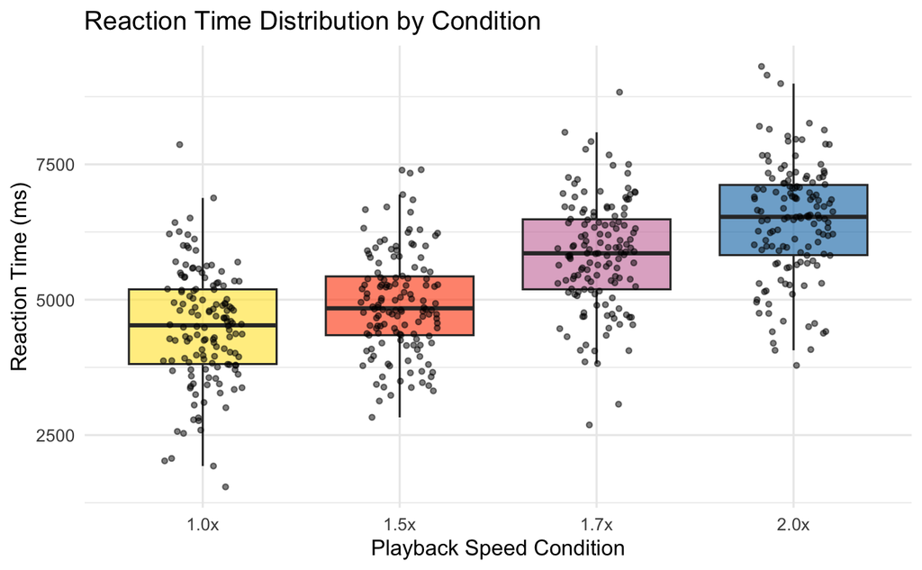

```r
# Plot reaction time by condition with actual data points
ggplot(long_data, aes(x = condition, y = reaction_time, fill = condition)) +
  geom_boxplot(alpha = 0.6, outlier.shape = NA) +
  geom_jitter(color = "black", size = 1, alpha = 0.5, width = 0.2) +  #individual data points
  scale_fill_manual(values = condition_colors) +
  theme_minimal() +
  labs(title = "Reaction Time Distribution by Condition",
       x = "Playback Speed Condition",
       y = "Reaction Time (ms)") +
  theme(legend.position = "none")
```

### Reaction time by Trials

*How does reaction time (and by extension, **attention**) distribution differ based on trial number (passage of time)?*

```r
# Descriptive stats by trial
summary_by_trial <- tapply(long_data$reaction_time, long_data$trial, summary)
print(summary_by_trial)
```

```
$`1`
   Min. 1st Qu.  Median    Mean 3rd Qu.    Max.
   1928    4542    5334    5363    6114    8092

$`2`
   Min. 1st Qu.  Median    Mean 3rd Qu.    Max.
   2532    4200    4796    5109    5992    7963

$`3`
   Min. 1st Qu.  Median    Mean 3rd Qu.    Max.
   2818    4538    5186    5361    6152    8832

$`4`
   Min. 1st Qu.  Median    Mean 3rd Qu.    Max.
   3102    4768    5740    5653    6425    8991

$`5`
   Min. 1st Qu.  Median    Mean 3rd Qu.    Max.
   2024    4495    5460    5442    6520    8260

$`6`
   Min. 1st Qu.  Median    Mean 3rd Qu.    Max.
   1543    4898    5577    5627    6517    9308
```

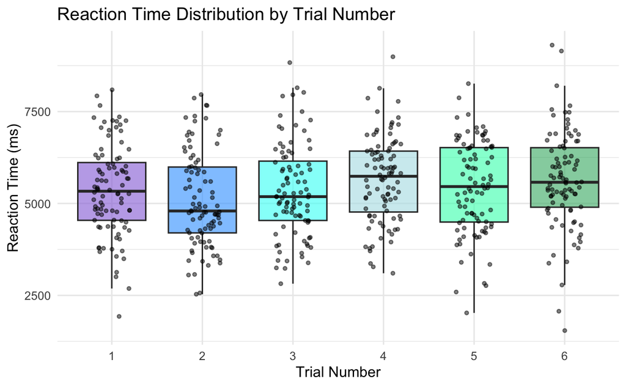

```r
# Plot reaction time by trial
ggplot(long_data, aes(x = factor(trial), y = reaction_time, fill = factor(trial))) +
  geom_boxplot(alpha = 0.6, outlier.shape = NA) +
  geom_jitter(color = "black", size = 1, alpha = 0.5, width = 0.2) +
  scale_fill_manual(values = cool_palette) +
  theme_minimal() +
  labs(title = "Reaction Time Distribution by Trial Number",
       x = "Trial Number",
       y = "Reaction Time (ms)") +
  theme(legend.position = "none")
```

# Inferential Statistics and Visualization

## Mixed Design ANOVA

```r
anova_model <- aov_ez(
  id = "participant_id",     # Participant ID
  dv = "reaction_time",      # Dependent variable
  within = "trial",          # Within-subjects factor (trial 1-6)
  between = "condition",     # Between-subjects factor (listening speed)
  data = long_data
)
```

```
Converting to factor: condition
Contrasts set to contr.sum for the following variables: condition
```

```r
summary(anova_model)  # View ANOVA results
```

```
Univariate Type III Repeated-Measures ANOVA Assuming Sphericity

                    Sum Sq num Df  Error SS den Df    F value    Pr(>F)
(Intercept)     1.6250e+10      1  73664374     88 19412.0350 < 2.2e-16 ***
condition       3.2357e+08      3  73664374     88   128.8450 < 2.2e-16 ***
trial           1.8465e+07      5 459978173    440     3.5325  0.003839 **
condition:trial 1.1063e+07     15 459978173    440     0.7055  0.779688
---
Signif. codes:  0 ‘***’ 0.001 ‘**’ 0.01 ‘*’ 0.05 ‘.’ 0.1 ‘ ’ 1


Mauchly Tests for Sphericity

                Test statistic p-value
trial                  0.89945 0.82311
condition:trial        0.89945 0.82311


Greenhouse-Geisser and Huynh-Feldt Corrections
 for Departure from Sphericity

                 GG eps Pr(>F[GG])
trial           0.96257   0.004364 **
condition:trial 0.96257   0.773971
---
Signif. codes:  0 ‘***’ 0.001 ‘**’ 0.01 ‘*’ 0.05 ‘.’ 0.1 ‘ ’ 1

                  HF eps  Pr(>F[HF])
trial           1.025027 0.003838925
condition:trial 1.025027 0.779687887
```

### Key Results:

**Condition × trial interaction**:

- F(15, 440)=0.71, p=0.780
- The interaction between condition and trial number is not significant.

Mauchly Tests for Sphericity yielded non-significant result for both trial and condition*trial interaction (*p=0.8231*), meaning that sphericity assumption has not been violated.

## Effect size

```r
eta_squared(anova_model)
```

```
# Effect Size for ANOVA (Type III)

Parameter       | Eta2 (partial) |       95% CI
-----------------------------------------------
condition       |           0.81 | [0.76, 1.00]
trial           |           0.04 | [0.01, 1.00]
condition:trial |           0.02 | [0.00, 1.00]

- One-sided CIs: upper bound fixed at [1.00].
```

**Condition:**

- η²p = 0.81, 95% CI: [0.76, 1.00]
- There is a very large effect of condition (speed levels) on reaction time.

**Trial:**

- η²p = 0.04, 95% CI: [0.01, 1.00]
- There is a small effect size of trial number on reaction time.

**Condition × Trial Interaction:**

- η²p = 0.02, 95% CI: [0.00, 1.00]
- There is a very small or negligible effect of the interaction on reaction time.

## Post hoc tests

### **Main effect for condition**

Since condition is a between-subject factor, Tukey’s HSD or Games-Howell can be used to test the main effect, depending on if the assumption of homogeneity of variance is violated.

```r
# checking homogeneity of variance asusmption
leveneTest(reaction_time ~ condition, data = long_data)
```

```
Levene's Test for Homogeneity of Variance (center = median)
       Df F value Pr(>F)
group   3  0.5764 0.6307
      548
```

Levene test result is not significant, meaning that the assumption of homogeneity of variance is not violated. Therefore, Tukey’s HSD can be used.

```r
#fitting the anova model to Tuckey HSD function
anova_model_fit <- aov(reaction_time ~ condition, data = long_data)

TukeyHSD(anova_model_fit)
```

```
  Tukey multiple comparisons of means
    95% family-wise confidence level

Fit: aov(formula = reaction_time ~ condition, data = long_data)

$condition
               diff       lwr       upr     p adj
1.5x-1.0x  439.7788  125.2883  754.2694 0.0019386
1.7x-1.0x 1337.8183 1023.3277 1652.3088 0.0000000
2.0x-1.0x 1965.9979 1651.5073 2280.4885 0.0000000
1.7x-1.5x  898.0394  583.5488 1212.5300 0.0000000
2.0x-1.5x 1526.2190 1211.7284 1840.7096 0.0000000
2.0x-1.7x  628.1796  313.6890  942.6702 0.0000022
```

Tukey’s HSD test reveals that all comparisons between conditions are significant.

- The largest difference is between 1.0x and 2.0 conditions (diff=1965.9979, p<.001)
- This result is to be expected given the simulation parameters.

### Visualization of main effect of condition

[figure not shown]

### **Main effect for time (trials)**:

Since the trial number is a within-subject factor, paired t-test can be used to test the main effect.

```r
#pairwise.t.test function
pairwise_results <- pairwise.t.test(
  long_data$reaction_time,
  long_data$trial,
  paired = TRUE,
  p.adjust.method = "bonferroni"
)

print(pairwise_results)
```

```
    Pairwise comparisons using paired t tests

data:  long_data$reaction_time and long_data$trial

  1     2     3     4     5
2 1.000 -     -     -     -
3 1.000 1.000 -     -     -
4 0.906 0.012 0.710 -     -
5 1.000 0.305 1.000 1.000 -
6 1.000 0.041 0.942 1.000 1.000

P value adjustment method: bonferroni
```

## Visualization of main effect of trial

[figure not shown]

```r
# Calculate mean and sd for each trial
trial_summary <- long_data %>%
  group_by(trial) %>%
  summarise(
    mean_rt = mean(reaction_time, na.rm = TRUE),
    sd_rt = sd(reaction_time, na.rm = TRUE),
    se_rt = sd_rt / sqrt(n())
  )

# bar plot with standard deviation error bars
trial_plot <- ggplot(trial_summary, aes(x = factor(trial), y = mean_rt, fill = factor(trial))) +
  geom_bar(stat = "identity", position = position_dodge(), alpha = 0.7) +
  geom_errorbar(aes(ymin = mean_rt - sd_rt, ymax = mean_rt + sd_rt),
                width = 0.2, position = position_dodge(0.9)) +
  scale_fill_manual(values = cool_palette) +
  theme_minimal() +
  labs(title = "Main Effect of Trial Number on Reaction Time",
       x = "Trial Number",
       y = "Mean Reaction Time (ms)",
       caption = "Error bars represent standard deviation") +
  theme(legend.position = "none")

# Add significance brackets for the significant trial comparisons
trial_plot +
  geom_signif(
    comparisons = list(c("2", "4"), c("2", "6")),
    map_signif_level = TRUE,
    y_position = c(max(trial_summary$mean_rt + trial_summary$sd_rt) * 1.05,
                  max(trial_summary$mean_rt + trial_summary$sd_rt) * 1.15),
    tip_length = 0.05,
    annotations = c("p<0.01", "p<0.05")
  )
```

## Visualization of interaction effect

Even though the interaction between condition and trial number is not significant, we can plot the reaction time by condition and trial to better visualize the dynamic change in attention throughout the experiment.

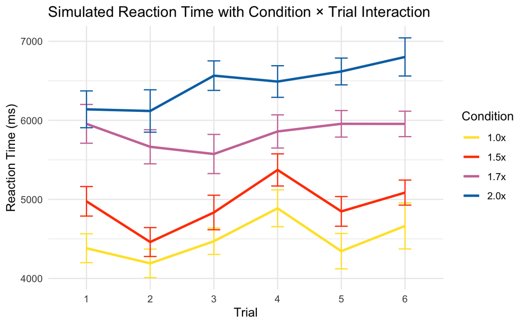

```r
condition_colors <- c("#FFE333","#FF4500", "#CC79A7", "#0072B2")

ggplot(long_data, aes(x = factor(trial), y = reaction_time, color = condition, group = condition)) +
  stat_summary(fun = mean, geom = "line", size = 1) +
  stat_summary(fun.data = mean_se, geom = "errorbar", width = 0.2) +
  scale_color_manual(values = condition_colors) +
  labs(title = "Simulated Reaction Time with Condition × Trial Interaction",
       x = "Trial",
       y = "Reaction Time (ms)",
       color = "Condition") +
  theme_minimal()
```